# 4RTNI - v6

# Precentral Grey Matter Volume

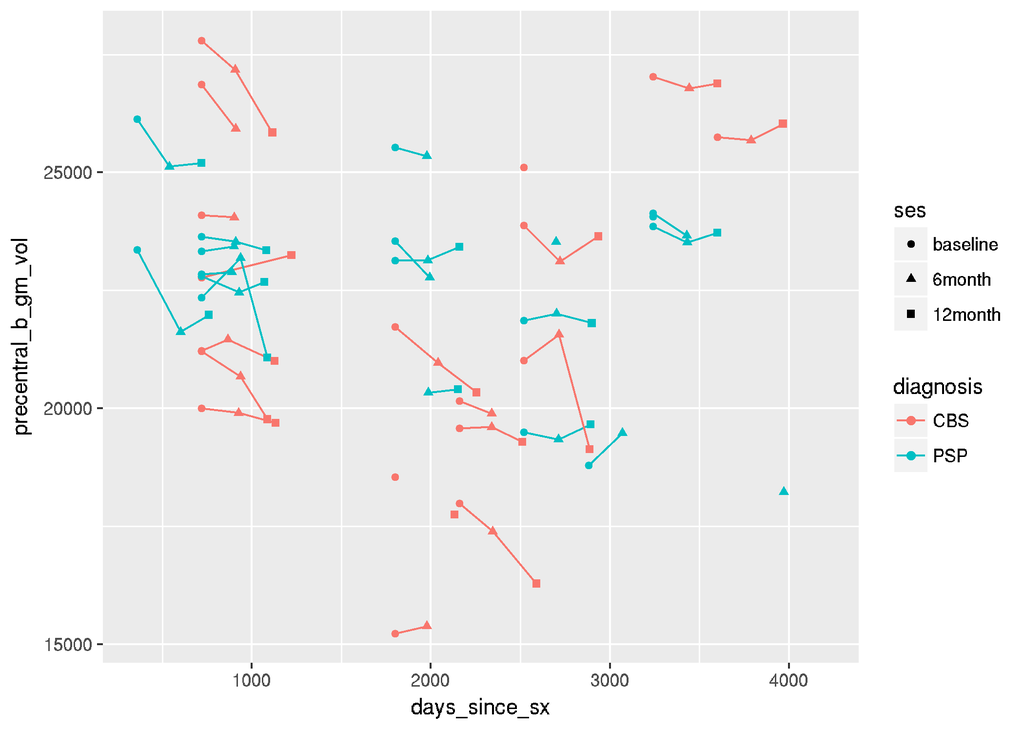

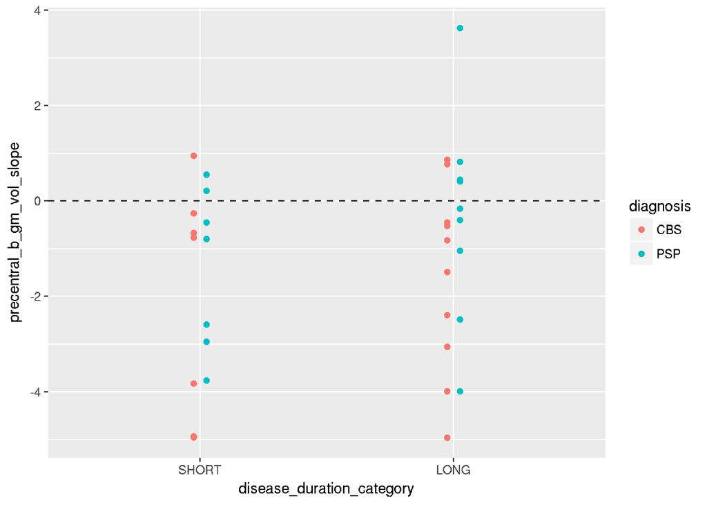

t.test for SHORT vs LONG group diff in slope among CBS:

```r
t.test(precentral_b_gm_vol_slope~disease_duration_category, data=mydata_long,subset= diagnosis=="CBS")$p.value
```

```
## [1] 0.6839698
```

t.test for SHORT vs LONG group diff in slope among PSP:

```r
t.test(precentral_b_gm_vol_slope~disease_duration_category, data=mydata_long,subset= diagnosis=="PSP")$p.value
```

```
## [1] 0.2747285
```

# Postcentral Grey Matter Volume

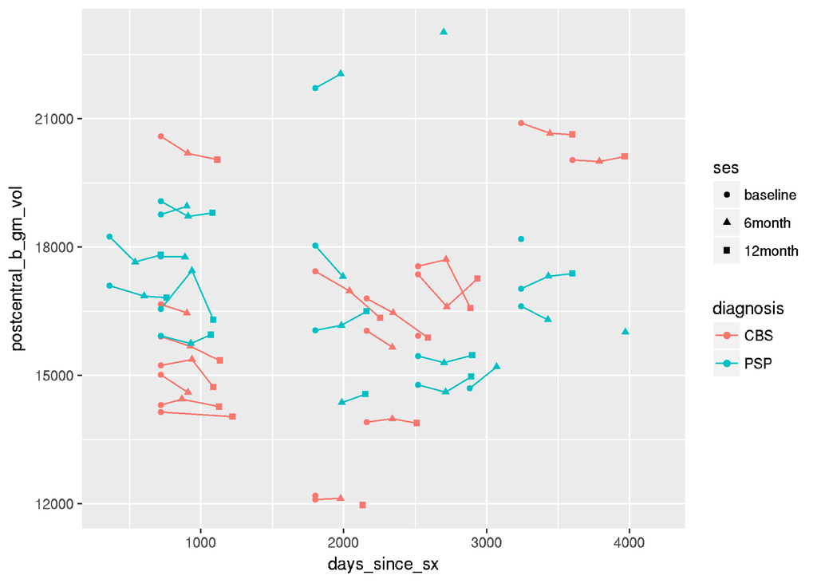

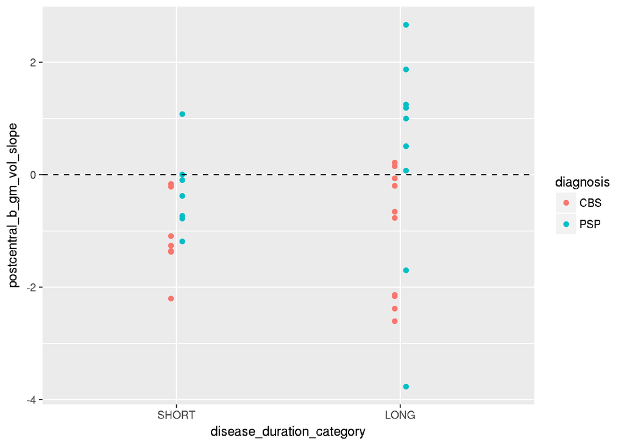

t.test for SHORT vs LONG group diff in slope among CBS:

```r
t.test(postcentral_b_gm_vol_slope~disease_duration_category, data=mydata_long,subset= diagnosis=="CBS")$p.value
```

```
## [1] 0.9413697
```

t.test for SHORT vs LONG group diff in slope among PSP:

```r
t.test(postcentral_b_gm_vol_slope~disease_duration_category, data=mydata_long,subset= diagnosis=="PSP")$p.value
```

```
## [1] 0.3870414
```

# Precentral White Matter Volume

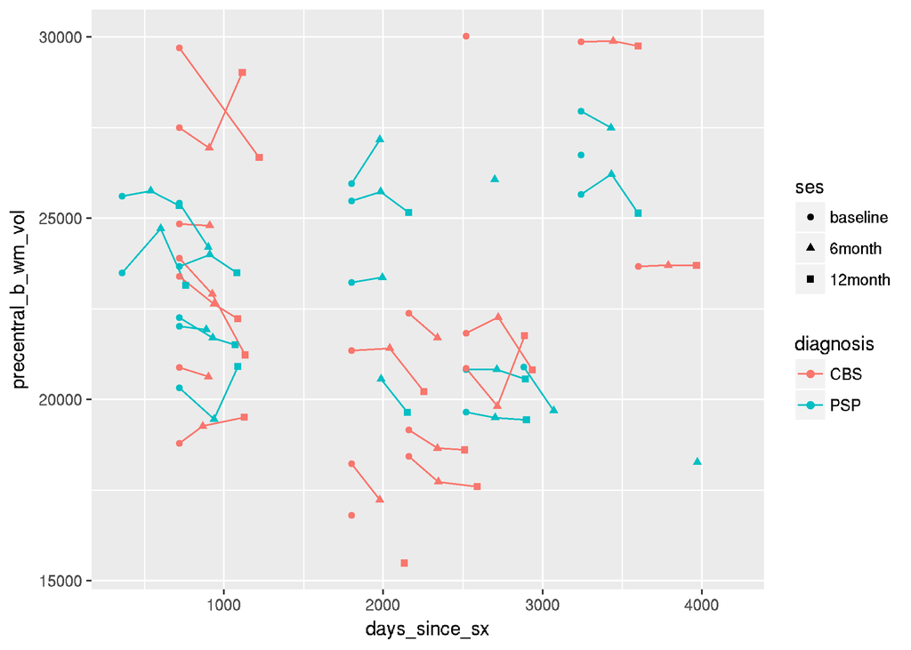

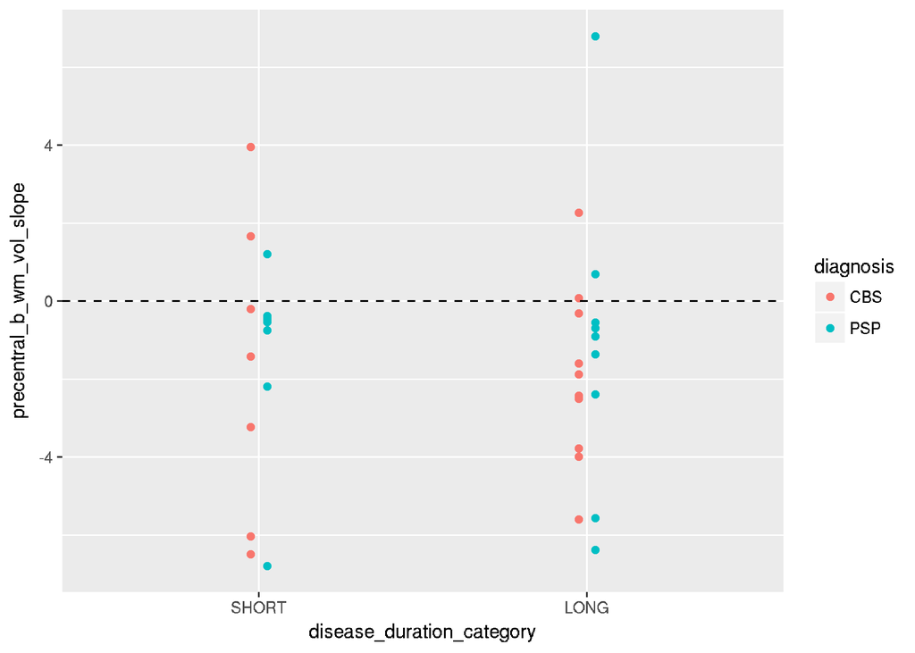

t.test for SHORT vs LONG group diff in slope among CBS:

```r
t.test(precentral_b_wm_vol_slope~disease_duration_category, data=mydata_long,subset= diagnosis=="CBS")$p.value
```

```
## [1] 0.8606234
```

t.test for SHORT vs LONG group diff in slope among PSP:

```r
t.test(precentral_b_wm_vol_slope~disease_duration_category, data=mydata_long,subset= diagnosis=="PSP")$p.value
```

```
## [1] 0.8716657
```

# Postcentral White Matter Volume

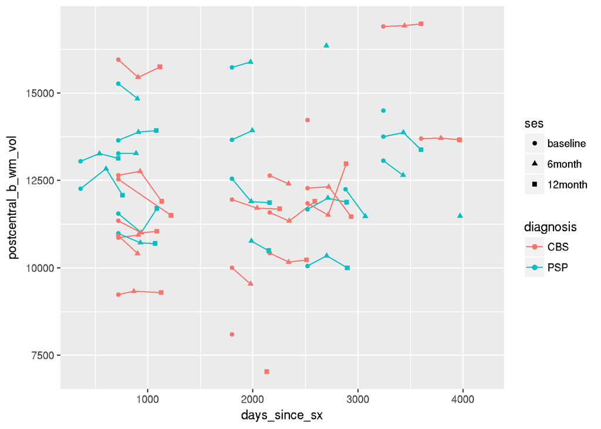

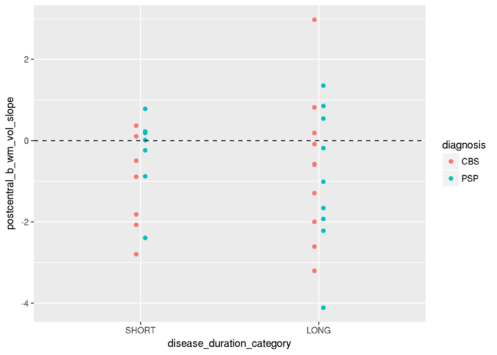

t.test for SHORT vs LONG group diff in slope among CBS:

```r
t.test(postcentral_b_wm_vol_slope~disease_duration_category, data=mydata_long,subset= diagnosis=="CBS")$p.value
```

```
## [1] 0.5450388
```

t.test for SHORT vs LONG group diff in slope among PSP:

```r
t.test(postcentral_b_wm_vol_slope~disease_duration_category, data=mydata_long,subset= diagnosis=="PSP")$p.value
```

```
## [1] 0.4081793
```

# Pons Volume

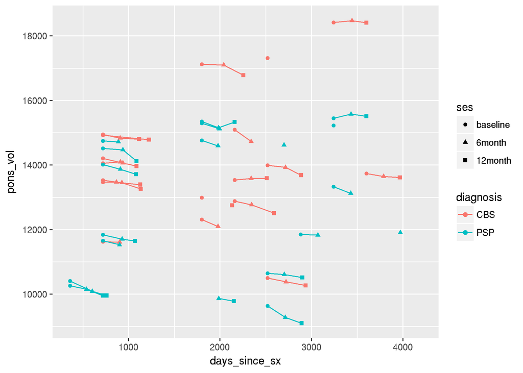

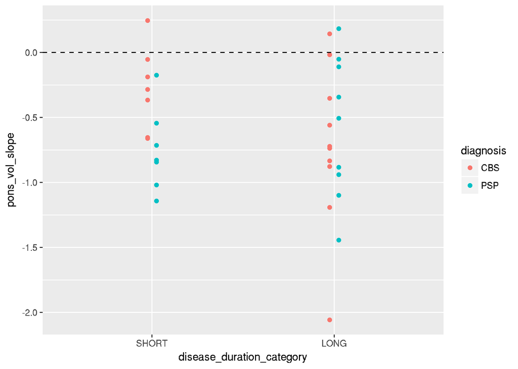

t.test for SHORT vs LONG group diff in slope among CBS:

```r
t.test(pons_vol_slope~disease_duration_category, data=mydata_long,subset= diagnosis=="CBS")$p.value
```

```
## [1] 0.07680427
```

t.test for SHORT vs LONG group diff in slope among PSP:

```r
t.test(pons_vol_slope~disease_duration_category, data=mydata_long,subset= diagnosis=="PSP")$p.value
```

```
## [1] 0.4369317
```

# Lateral Occipital Grey Matter Volume

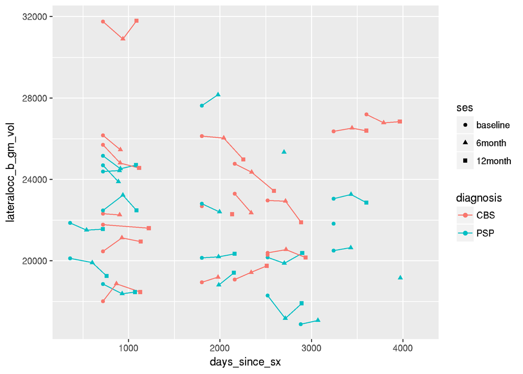

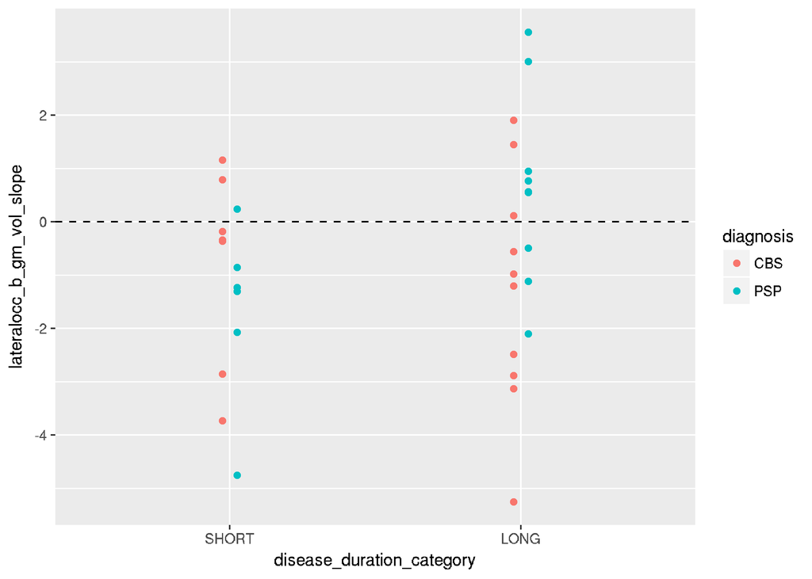

t.test for SHORT vs LONG group diff in slope among CBS:

```r
t.test(lateralocc_b_gm_vol_slope~disease_duration_category, data=mydata_long,subset= diagnosis=="CBS")$p.value
```

```
## [1] 0.6076556
```

t.test for SHORT vs LONG group diff in slope among PSP:

```r
t.test(lateralocc_b_gm_vol_slope~disease_duration_category, data=mydata_long,subset= diagnosis=="PSP")$p.value
```

```
## [1] 0.03847049
```

# Lateral Occipital White Matter Volume

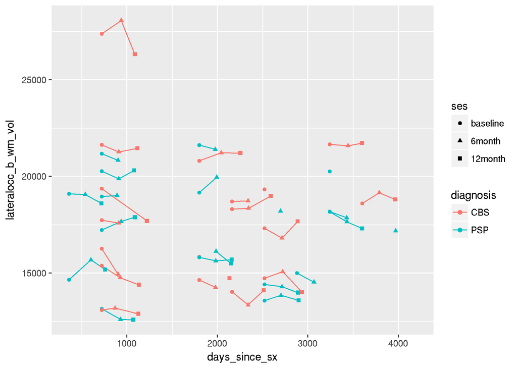

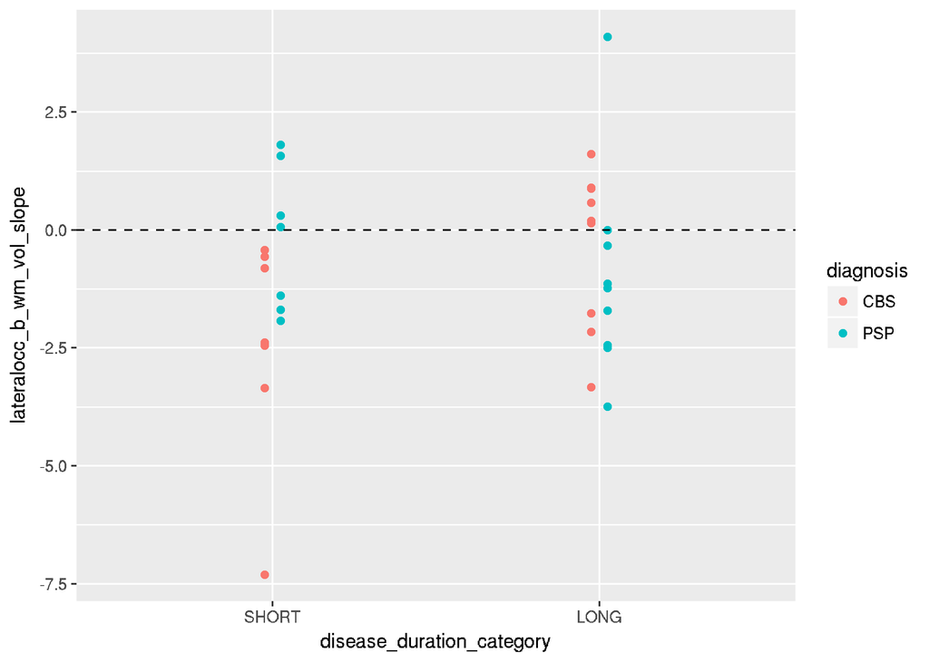

t.test for SHORT vs LONG group diff in slope among CBS:

```r
t.test(lateralocc_b_wm_vol_slope~disease_duration_category, data=mydata_long,subset= diagnosis=="CBS")$p.value
```

```
## [1] 0.06243093
```

t.test for SHORT vs LONG group diff in slope among PSP:

```r
t.test(lateralocc_b_wm_vol_slope~disease_duration_category, data=mydata_long,subset= diagnosis=="PSP")$p.value
```

```
## [1] 0.3991278
```

# V1 Grey Matter Volume

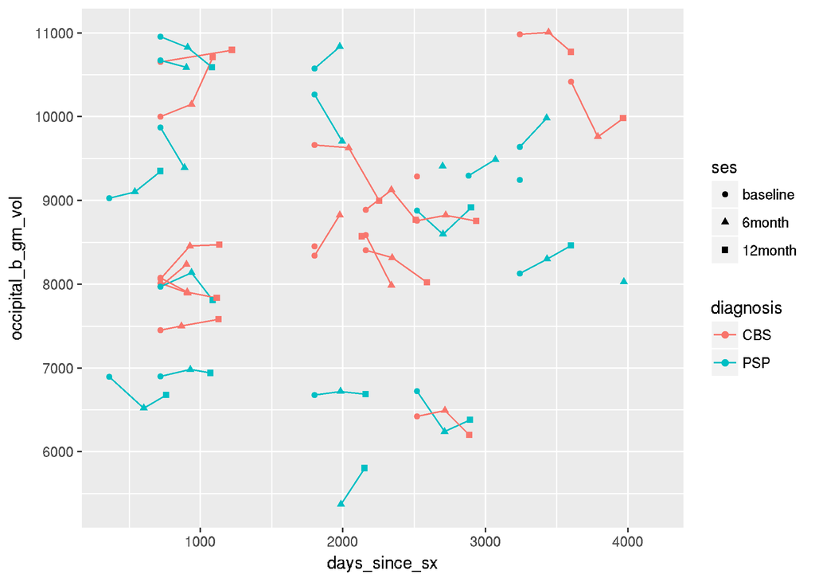

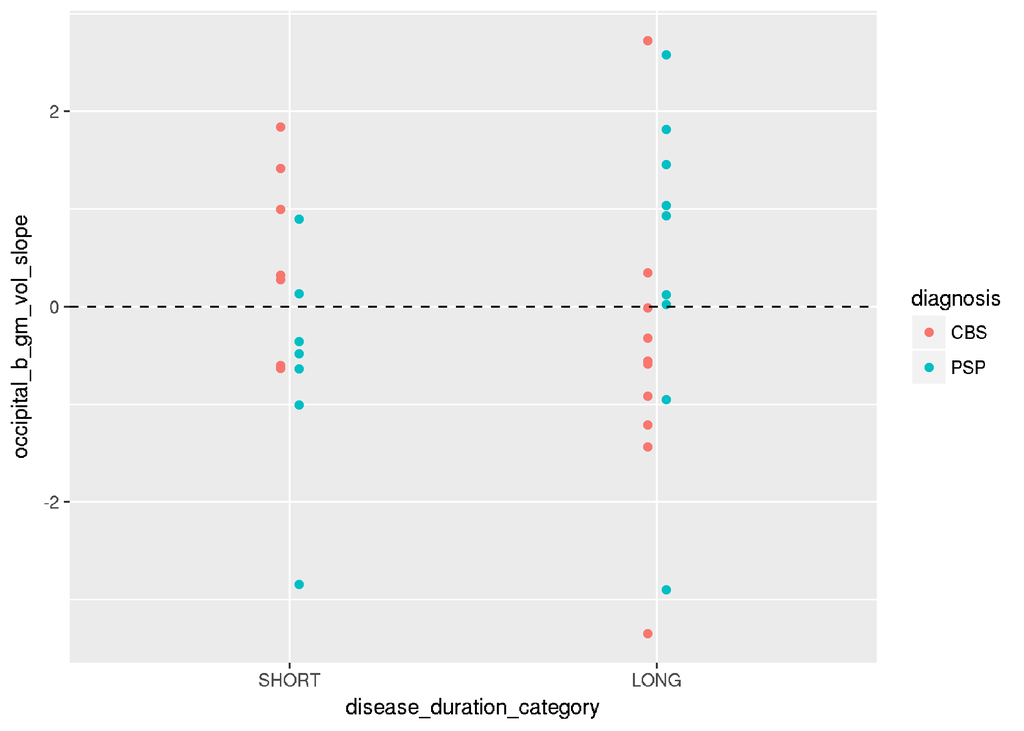

t.test for SHORT vs LONG group diff in slope among CBS:

```r
t.test(occipital_b_gm_vol_slope~disease_duration_category, data=mydata_long,subset= diagnosis=="CBS")$p.value
```

```
## [1] 0.1022216
```

t.test for SHORT vs LONG group diff in slope among PSP:

```r
t.test(occipital_b_gm_vol_slope~disease_duration_category, data=mydata_long,subset= diagnosis=="PSP")$p.value
```

```
## [1] 0.1487805
```

# ===============================

# Demographic Tables

for PSP

```r
demo_table_PSP
```

```
##                                       Stratified by disease_duration_category
##                                        SHORT         LONG          p      test
##   n                                        8            12
##   age_at_baseline (mean (SD))          66.12 (8.59)  71.64 (7.84)   0.164
##   sex_baseline = M (%)                     3 (37.5)      4 (36.4)   1.000
##   months_since_sx_baseline (mean (SD)) 21.00 (5.55)  78.55 (19.62) <0.001
##   EDUCATION (mean (SD))                13.88 (1.55)  16.08 (3.82)   0.141
##   CDR_0_CDRTOT (mean (SD))              0.62 (0.23)   0.71 (0.58)   0.707
##   CDR_0_BOXSCORE (mean (SD))            3.50 (2.00)   4.21 (3.31)   0.595
##   PSPRS_0_TOTAL (mean (SD))            23.75 (5.04)  42.10 (15.43)  0.005
##   MOCA_0_MOCATOTWITHEDUC (mean (SD))   23.00 (2.62)  20.00 (5.79)   0.222
```

for CBS

```r
demo_table_CBS
```

```
##                                       Stratified by disease_duration_category
##                                        SHORT         LONG          p      test
##   n                                        8            10
##   age_at_baseline (mean (SD))          62.25 (5.28)  67.10 (6.97)   0.123
##   sex_baseline = M (%)                     4 (50.0)      4 (40.0)   1.000
##   months_since_sx_baseline (mean (SD)) 22.50 (4.24)  79.20 (20.55) <0.001
##   EDUCATION (mean (SD))                20.38 (4.60)  16.00 (2.49)   0.020
##   CDR_0_CDRTOT (mean (SD))              0.56 (0.32)   0.55 (0.37)   0.941
##   CDR_0_BOXSCORE (mean (SD))            2.62 (2.08)   2.90 (2.12)   0.786
##   PSPRS_0_TOTAL (mean (SD))            19.88 (6.73)  23.78 (12.07)  0.432
##   MOCA_0_MOCATOTWITHEDUC (mean (SD))   21.50 (6.83)  20.00 (7.46)   0.707
```

# raw values tables

for PSP

```r
print(PSP_table,digits=7)
```

```
##                                                Stratified by disease_duration_category
##                                                 SHORT                      LONG                       p      test
##   n                                             8                          12
##   total_wm_vol_slope_mo (mean (SD))             -620.8764270 (693.7916324) -496.9695893 (801.6633535)  0.750
##   total_gm_vol_slope_mo (mean (SD))             -733.9975224 (505.1420838) -266.4070756 (716.0946057)  0.166
##   scp_b_fa_slope_mo (mean (SD))                   -0.0029647 (0.0028237)     -0.0019048 (0.0034722)    0.482
##   corpuscallosum_fa_slope_mo (mean (SD))          -0.0014116 (0.0016898)     -0.0005954 (0.0025587)    0.439
##   caudate_b_md_slope_mo (mean (SD))                0.0024675 (0.0054491)      0.0041724 (0.0085216)    0.623
##   thalamus_b_md_slope_mo (mean (SD))               0.0013567 (0.0018775)      0.0008683 (0.0021918)    0.612
##   midbrain_md_slope_mo (mean (SD))                 0.0014686 (0.0047727)      0.0004357 (0.0034409)    0.580
##   precentral_b_fa_slope_mo (mean (SD))            -0.0012496 (0.0006507)     -0.0000967 (0.0007817)    0.003
##   postcentral_b_fa_slope_mo (mean (SD))           -0.0012846 (0.0010388)      0.0001876 (0.0007475)    0.002
##   pons_md_slope_mo (mean (SD))                     0.0012219 (0.0023702)      0.0002770 (0.0024385)    0.402
##   occipital_b_fa_slope_mo (mean (SD))             -0.0005650 (0.0009797)      0.0000227 (0.0011695)    0.257
##   scp_vol_slope_mo (mean (SD))                    -0.6547267 (1.4034402)     -0.0435433 (1.6699483)    0.450
##   corpuscallosum_total_vol_slope_mo (mean (SD))   -4.6652990 (2.6674904)     -2.1124262 (3.5353459)    0.135
##   caudate_b_vol_slope_mo (mean (SD))             -13.5174872 (18.9671882)   -12.9766529 (12.9840777)   0.947
##   thalamus_b_vol_slope_mo (mean (SD))            -22.9653639 (19.5433815)   -10.3441685 (29.9609024)   0.352
##   midbrain_vol_slope_mo (mean (SD))               -4.1270692 (10.6017198)    -9.7284189 (13.4385372)   0.373
##   precentral_b_gm_vol_slope_mo (mean (SD))       -41.9416770 (50.6097956)    -9.3034939 (64.2312308)   0.289
##   postcentral_b_gm_vol_slope_mo (mean (SD))       -8.9514288 (22.0490765)    10.2871619 (58.9139872)   0.428
##   precentral_b_wm_vol_slope_mo (mean (SD))       -42.3811836 (76.9829288)   -34.5047629 (113.9973597)  0.878
##   postcentral_b_wm_vol_slope_mo (mean (SD))       -9.8041356 (31.2183149)   -27.8193487 (52.4473849)   0.436
##   lateralocc_b_gm_vol_slope_mo (mean (SD))       -41.7891163 (51.1334404)    18.9380240 (54.2190483)   0.039
##   lateralocc_b_wm_vol_slope_mo (mean (SD))        -5.3605446 (46.0654401)   -29.9845007 (66.9452510)   0.421
##   occipital_b_gm_vol_slope_mo (mean (SD))        -18.3989865 (34.7755986)    13.7120955 (49.1640795)   0.166
```

for CBS

```r
print(CBS_table,digits=7)
```

```
##                                                Stratified by disease_duration_category
##                                                 SHORT                      LONG                       p      test
##   n                                             8                          10
##   total_wm_vol_slope_mo (mean (SD))             -878.9660537 (640.3795567) -667.4984272 (584.7390615)  0.491
##   total_gm_vol_slope_mo (mean (SD))             -849.7624129 (469.0665433) -720.7923387 (794.2985330)  0.707
##   scp_b_fa_slope_mo (mean (SD))                   -0.0003264 (0.0045038)     -0.0010193 (0.0015101)    0.653
##   corpuscallosum_fa_slope_mo (mean (SD))          -0.0003047 (0.0022517)      0.0004263 (0.0036589)    0.628
##   caudate_b_md_slope_mo (mean (SD))                0.0043679 (0.0049632)      0.0028944 (0.0029870)    0.446
##   thalamus_b_md_slope_mo (mean (SD))              -0.0000754 (0.0016122)      0.0000830 (0.0016798)    0.842
##   midbrain_md_slope_mo (mean (SD))                -0.0002471 (0.0015398)     -0.0009560 (0.0027066)    0.520
##   precentral_b_fa_slope_mo (mean (SD))            -0.0002853 (0.0009971)     -0.0000798 (0.0014261)    0.735
##   postcentral_b_fa_slope_mo (mean (SD))           -0.0004105 (0.0007601)     -0.0001204 (0.0011547)    0.550
##   pons_md_slope_mo (mean (SD))                    -0.0006692 (0.0026809)     -0.0008883 (0.0048373)    0.910
##   occipital_b_fa_slope_mo (mean (SD))              0.0000535 (0.0009416)      0.0006881 (0.0018730)    0.397
##   scp_vol_slope_mo (mean (SD))                    -0.5040479 (1.5528269)      0.2924043 (1.7133726)    0.343
##   corpuscallosum_total_vol_slope_mo (mean (SD))   -3.2054342 (5.0595738)     -2.4335832 (3.6703361)    0.720
##   caudate_b_vol_slope_mo (mean (SD))             -15.5646981 (29.1720855)   -16.5244219 (11.8321025)   0.926
##   thalamus_b_vol_slope_mo (mean (SD))            -35.9032978 (18.0810768)   -29.4340913 (17.6702023)   0.473
##   midbrain_vol_slope_mo (mean (SD))               -1.1073569 (9.1962672)    -12.4162977 (10.8753533)   0.041
##   precentral_b_gm_vol_slope_mo (mean (SD))       -62.0282482 (73.0971035)   -48.1130742 (58.7782916)   0.670
##   postcentral_b_gm_vol_slope_mo (mean (SD))      -32.8462627 (21.3492562)   -31.8398615 (34.0466412)   0.946
##   precentral_b_wm_vol_slope_mo (mean (SD))       -50.3659112 (116.0198336)  -59.1886169 (67.7925069)   0.845
##   postcentral_b_wm_vol_slope_mo (mean (SD))      -32.5015894 (35.4065929)   -19.1033448 (53.7587425)   0.574
##   lateralocc_b_gm_vol_slope_mo (mean (SD))       -23.6592318 (54.6948916)   -39.0603854 (65.8579059)   0.619
##   lateralocc_b_wm_vol_slope_mo (mean (SD))       -73.9986982 (72.1743100)    -8.3389440 (47.6505934)   0.038
##   occipital_b_gm_vol_slope_mo (mean (SD))         15.5612548 (28.6065958)   -15.9491445 (45.8796395)   0.130
```

All, split by disease duration group

```r
print(LS_table,digits=6)
```

```
##                                                Stratified by disease_duration_category
##                                                 SHORT                    LONG                     p      test
##   n                                             16                       22
##   total_wm_vol_slope_mo (mean (SD))             -749.921240 (655.258770) -586.721609 (681.352363)  0.495
##   total_gm_vol_slope_mo (mean (SD))             -791.879968 (472.151945) -505.557214 (773.107726)  0.230
##   scp_b_fa_slope_mo (mean (SD))                   -0.001646 (0.003878)     -0.001502 (0.002738)    0.894
##   corpuscallosum_fa_slope_mo (mean (SD))          -0.000858 (0.002006)     -0.000131 (0.003072)    0.414
##   caudate_b_md_slope_mo (mean (SD))                0.003418 (0.005130)      0.003591 (0.006503)    0.930
##   thalamus_b_md_slope_mo (mean (SD))               0.000641 (0.001845)      0.000511 (0.001971)    0.839
##   midbrain_md_slope_mo (mean (SD))                 0.000611 (0.003539)     -0.000197 (0.003138)    0.463
##   precentral_b_fa_slope_mo (mean (SD))            -0.000767 (0.000954)     -0.000089 (0.001092)    0.054
##   postcentral_b_fa_slope_mo (mean (SD))           -0.000848 (0.000988)      0.000048 (0.000943)    0.008
##   pons_md_slope_mo (mean (SD))                     0.000276 (0.002632)     -0.000253 (0.003674)    0.627
##   occipital_b_fa_slope_mo (mean (SD))             -0.000256 (0.000982)      0.000325 (0.001528)    0.191
##   scp_vol_slope_mo (mean (SD))                    -0.579387 (1.424105)      0.133271 (1.654375)    0.205
##   corpuscallosum_total_vol_slope_mo (mean (SD))   -3.935367 (3.958904)     -2.281456 (3.509671)    0.214
##   caudate_b_vol_slope_mo (mean (SD))             -14.541093 (23.663112)   -14.843900 (12.175337)   0.962
##   thalamus_b_vol_slope_mo (mean (SD))            -29.434331 (19.293443)   -20.391496 (25.514260)   0.275
##   midbrain_vol_slope_mo (mean (SD))               -2.617213 (9.662465)    -11.072358 (11.977900)   0.036
##   precentral_b_gm_vol_slope_mo (mean (SD))       -51.984963 (61.293351)   -29.729589 (62.908112)   0.318
##   postcentral_b_gm_vol_slope_mo (mean (SD))      -20.898846 (24.258362)   -11.884956 (50.884310)   0.545
##   precentral_b_wm_vol_slope_mo (mean (SD))       -46.373547 (94.683678)   -47.496265 (90.741306)   0.973
##   postcentral_b_wm_vol_slope_mo (mean (SD))      -21.152863 (34.162925)   -23.231978 (51.841478)   0.897
##   lateralocc_b_gm_vol_slope_mo (mean (SD))       -32.724174 (51.729611)   -11.587455 (66.033190)   0.329
##   lateralocc_b_wm_vol_slope_mo (mean (SD))       -39.679621 (68.205640)   -18.592102 (57.012619)   0.341
##   occipital_b_gm_vol_slope_mo (mean (SD))         -1.418866 (35.303759)    -1.899083 (48.561958)   0.975
```

All, split by diagnosis

```r
print(diag_table,digits=6)
```

```
##                                                Stratified by Diagnosis
##                                                 CBS                      PSP                      p      test
##   n                                             18                       20
##   total_wm_vol_slope_mo (mean (SD))             -754.573332 (598.013849) -551.178831 (734.386188)  0.388
##   total_gm_vol_slope_mo (mean (SD))             -773.897663 (664.587369) -470.977896 (657.988920)  0.198
##   scp_b_fa_slope_mo (mean (SD))                   -0.000711 (0.003112)     -0.002329 (0.003194)    0.123
##   corpuscallosum_fa_slope_mo (mean (SD))           0.000101 (0.003052)     -0.000922 (0.002238)    0.243
##   caudate_b_md_slope_mo (mean (SD))                0.003549 (0.003929)      0.003490 (0.007329)    0.976
##   thalamus_b_md_slope_mo (mean (SD))               0.000013 (0.001603)      0.001064 (0.002035)    0.088
##   midbrain_md_slope_mo (mean (SD))                -0.000641 (0.002233)      0.000849 (0.003939)    0.166
##   precentral_b_fa_slope_mo (mean (SD))            -0.000171 (0.001224)     -0.000558 (0.000920)    0.275
##   postcentral_b_fa_slope_mo (mean (SD))           -0.000249 (0.000983)     -0.000401 (0.001126)    0.662
##   pons_md_slope_mo (mean (SD))                    -0.000791 (0.003919)      0.000655 (0.002395)    0.174
##   occipital_b_fa_slope_mo (mean (SD))              0.000406 (0.001526)     -0.000212 (0.001110)    0.159
##   scp_vol_slope_mo (mean (SD))                    -0.035547 (1.648871)     -0.310936 (1.540531)    0.624
##   corpuscallosum_total_vol_slope_mo (mean (SD))   -2.751404 (4.163015)     -3.229308 (3.350062)    0.720
##   caudate_b_vol_slope_mo (mean (SD))             -16.129241 (19.952825)   -13.213268 (15.293500)   0.642
##   thalamus_b_vol_slope_mo (mean (SD))            -32.097882 (17.578400)   -15.865941 (25.948835)   0.043
##   midbrain_vol_slope_mo (mean (SD))               -7.759675 (11.452354)    -7.421981 (12.321016)   0.935
##   precentral_b_gm_vol_slope_mo (mean (SD))       -53.842852 (63.221049)   -23.582699 (59.198954)   0.166
##   postcentral_b_gm_vol_slope_mo (mean (SD))      -32.254262 (28.691766)     1.870278 (46.289808)   0.015
##   precentral_b_wm_vol_slope_mo (mean (SD))       -55.555738 (87.480907)   -37.950697 (96.528299)   0.587
##   postcentral_b_wm_vol_slope_mo (mean (SD))      -24.620269 (46.281039)   -19.937693 (44.069061)   0.768
##   lateralocc_b_gm_vol_slope_mo (mean (SD))       -32.718734 (60.187856)    -7.630100 (59.847623)   0.239
##   lateralocc_b_wm_vol_slope_mo (mean (SD))       -35.375313 (65.879630)   -19.211520 (58.294049)   0.462
##   occipital_b_gm_vol_slope_mo (mean (SD))         -2.974274 (41.790347)    -0.336503 (45.205419)   0.863
```